# GCCR Factor Influence

# The Factors Performance. USA. GCCR

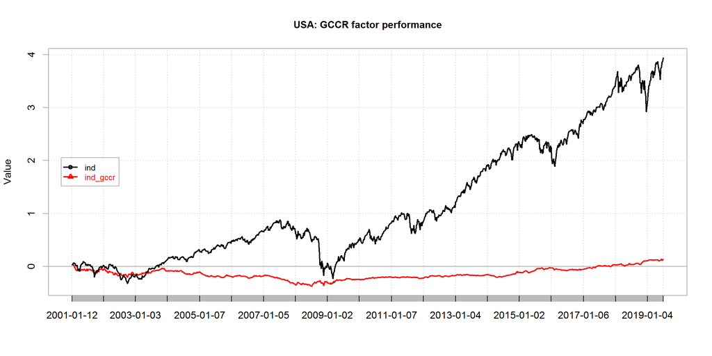

# The Factors Performance. USA. GCCR. Summary

- The factor is designed as follows: go long with all 1 and short all 0. Since 1 or 0 does not really matter if you know that the company still survived in the index, the return is expected to be around 0.
- However, the recent data (no spoiled by backward filling) could be promissing. Here we see an increase.
- The benchmark here is equal-weighted index.

# The Factors Performance. USA. Value

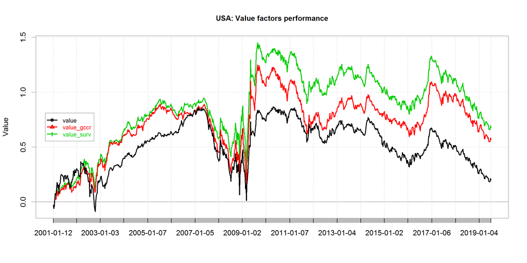

# The Factors Performance. USA. Value. Summary

- Original: poor performance (this is a fact).
- Survived (0 and 1): the performance is significantly improved by the survivorship bias.
- Good (Only 1): The filter lowers the performance compared with survived case.

# The Factors Performance. USA. Momentum

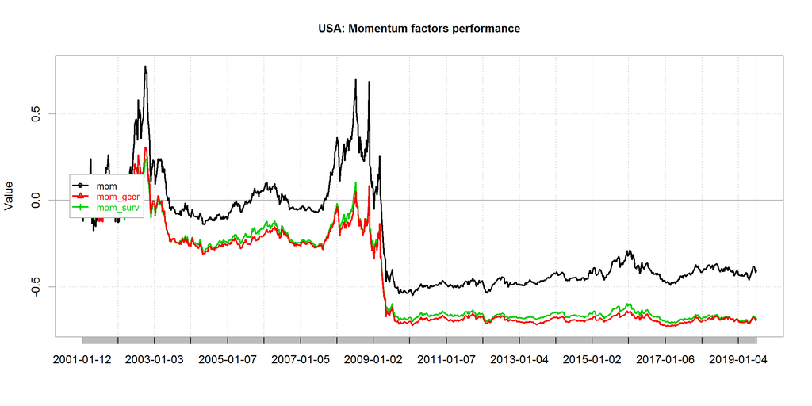

# The Factors Performance. USA. Momentum. Summary

- Original: poor performance (negative).
- Survived (0 and 1): Survived portfolio performed worse than just original one.
- Good (Only 1): the same as in the survived case. (no effect).

# The Factors Performance. USA. Size

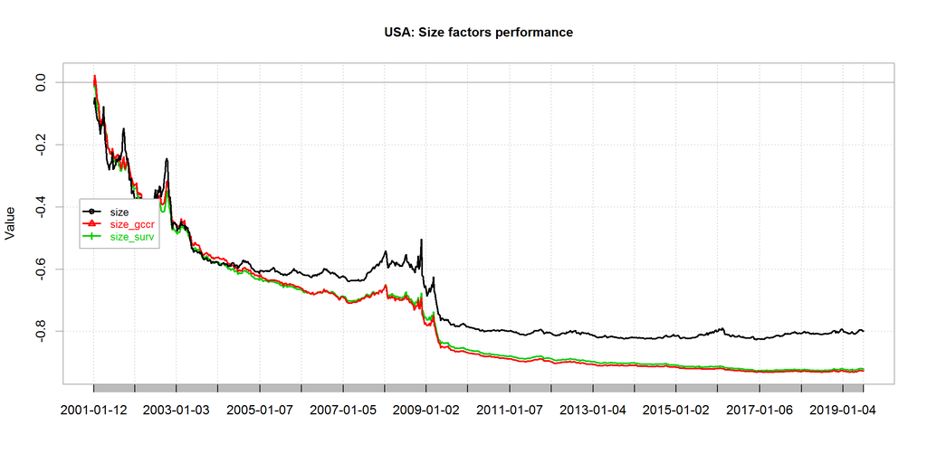

# The Factors Performance. USA. Size. Summary

- Survived (0 and 1): The original size factor performed significantly better than the Survived one, which shows negative performance all the time.
- Good (Only 1): there is no additional effect.

# The Factors Performance. EUR. GCCR

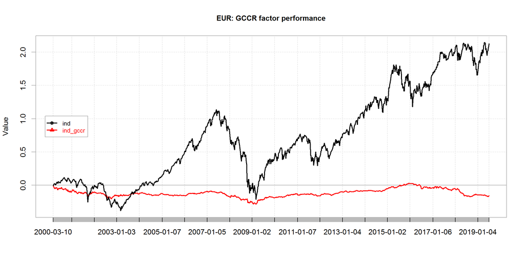

# The Factors Performance. EUR. GCCR. Summary

- The performance is negative, but still around 0. This is expected in case if filtering does not help.
- Negative performance means that 1s portfolio performed worse than 0s. One should keep in mind backward filling bias (all companies have survived).
- Interestingly, after 2016 (with the most recent data) the trend goes down, meaning that 0s portfolio performs a bit better.
- The benchmark here is equal-weighted index.

# The Factors Performance. EUR. Value

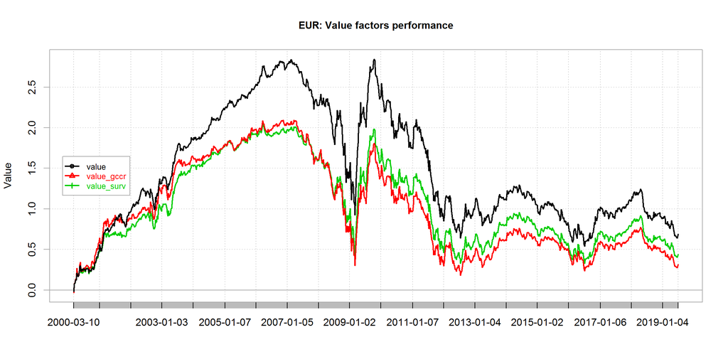

# The Factors Performance. EUR. Value. Summary

- Survived (0 and 1): The survivorship bias lowers the performance.
- Good (Only 1): The effect is increased.

# The Factors Performance. EUR. Momentum

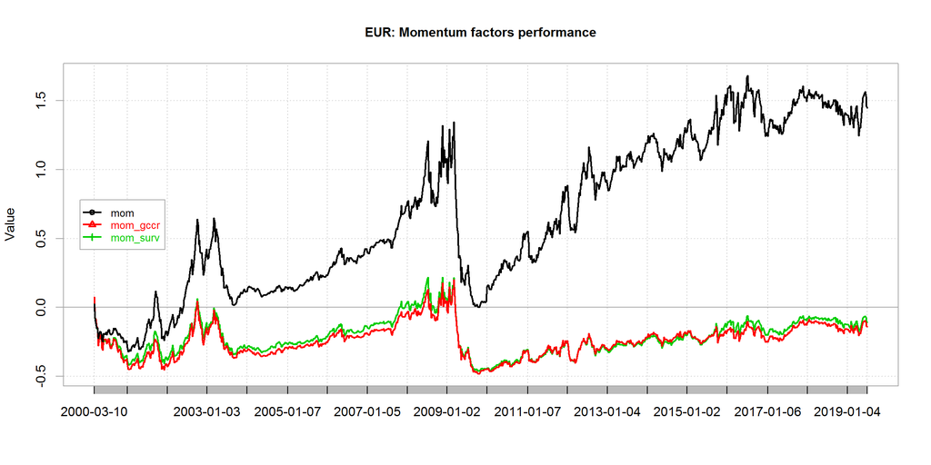

# The Factors Performance. EUR. Momentum. Summary

- Original Momentum performs positively.
- Survived (0 and 1): SustFilter significantly lowers the performance of Momentum factor in Europe.

# The Factors Performance. EUR. Size

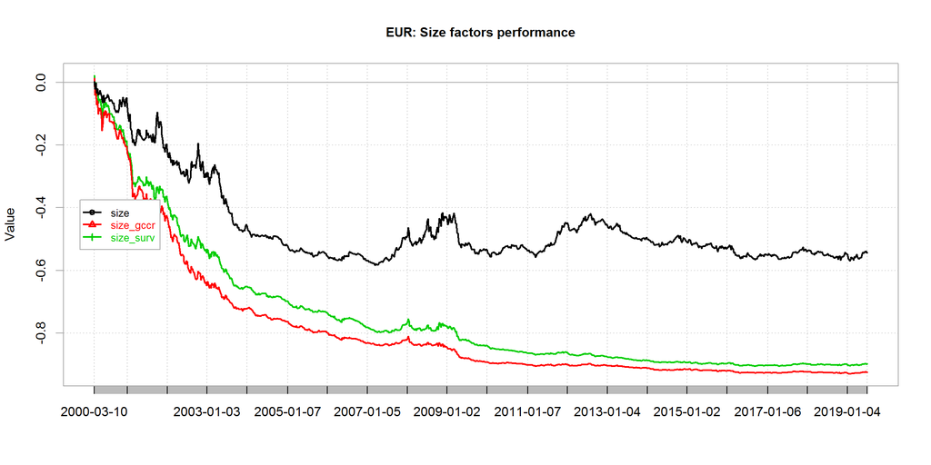

# The Factors Performance. EUR. Size. Summary

- Original Size performs negatively.
- Survived (0 and 1): The survivorship bias significantly lowers the performance of Size factor in Europe.
- Good (Only 1): The filter increases the survivorship bias effect.

# The Factors Performance. EM. GCCR

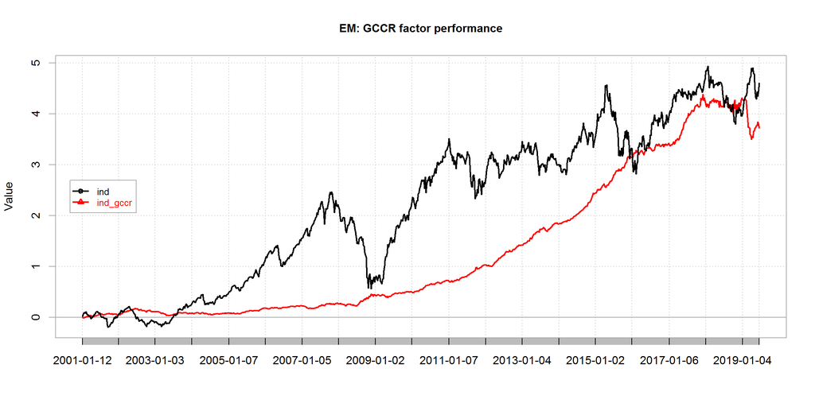

# The Factors Performance. EM. GCCR. Summary

- The results here are really promissing. 1s Portfolio significantly outperformed 0s.
- However, the performance is comparable to the performance of the equal-weighted index.

# The Factors Performance. EM. Value

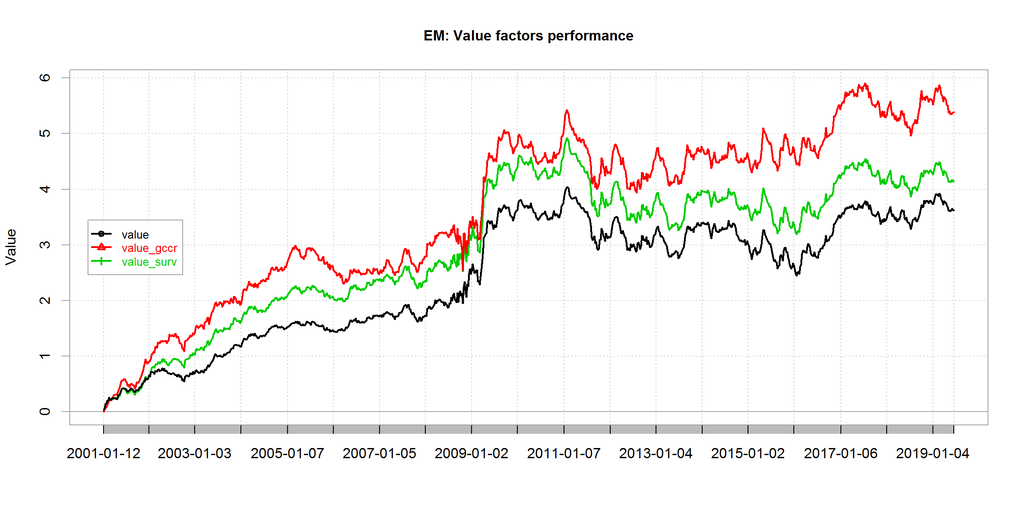

# The Factors Performance. EM. Value. Summary

- Original: performance is positive and much better than in the U.S. and the European markets.
- Survived (0 and 1): the survivorship bias increases the factor performance.
- Good (Only 1): the filtering also helps.

# The Factors Performance. EM. Momentum

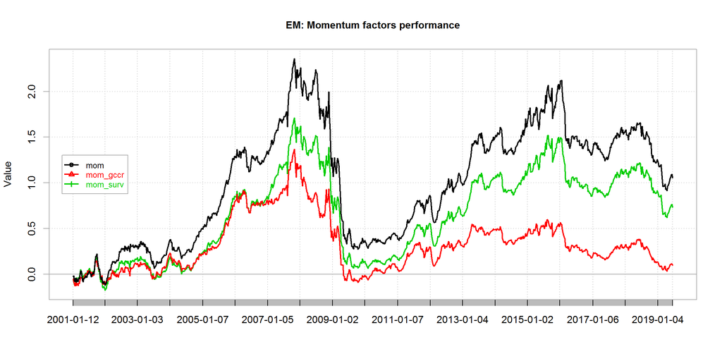

# The Factors Performance. EM. Momentum. Summary

- Original MOM performance is positive.
- Survived (0 and 1): the survivorship bias lowers Momentum performance in the EM.
- Good (Only 1): The filter lowers Momentum performance further.

# The Factors Performance. EM. Size

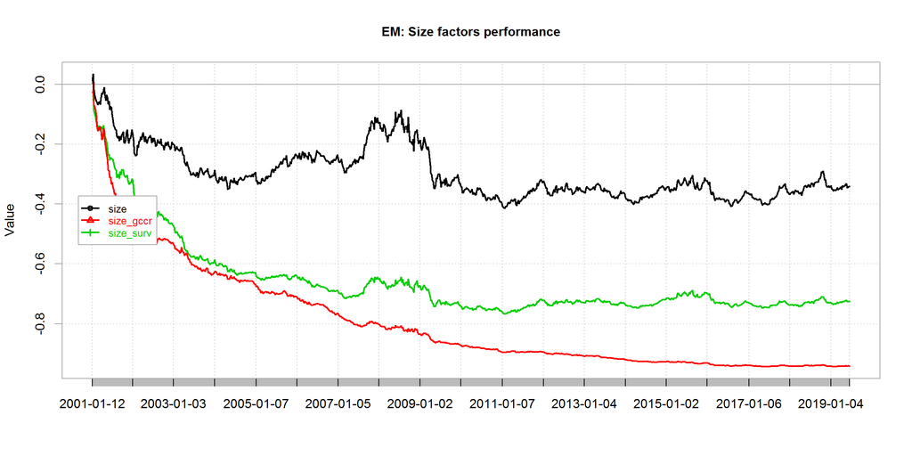

# The Factors Performance. EM. Size. Summary

- Original: the factor shows negative performance.
- Survived (0 and 1): The survivorship bias significantly lowers Size performance in the EM.
- Good (Only 1): the survivorship bias effect is increased.

# The Factors Performance. JBonds. BM

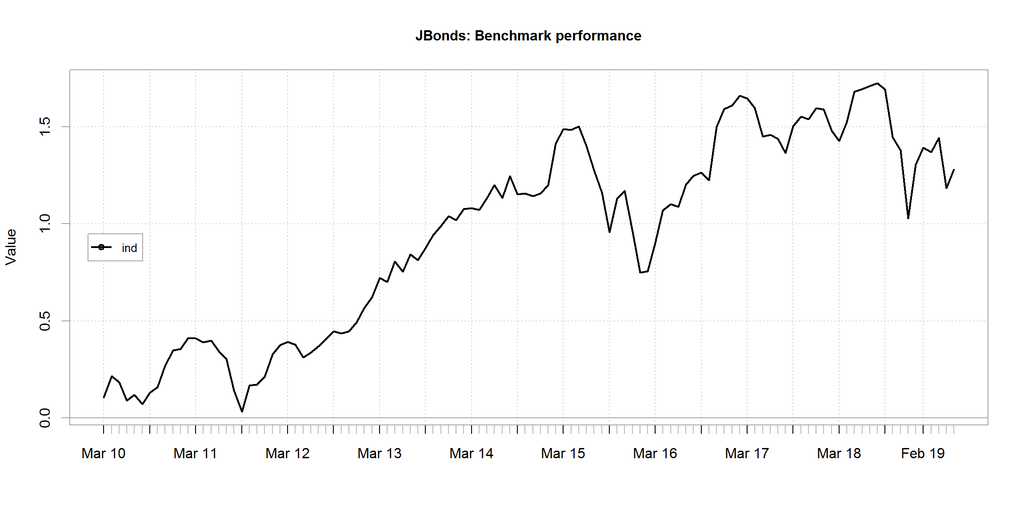

# The Factors Performance. JBonds. BM. Summary

- Equally weighted index is positive.

# The Factors Performance. JBonds. GCCR

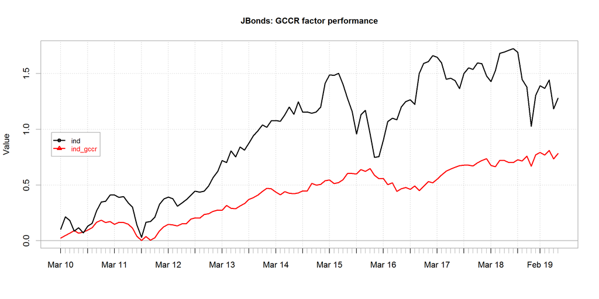

# The Factors Performance. JBonds. GCCR. Summary

- The factor based on SustFilter has lower performance than the equal-weighted index.

# The Factors Performance. JBonds. Momentum

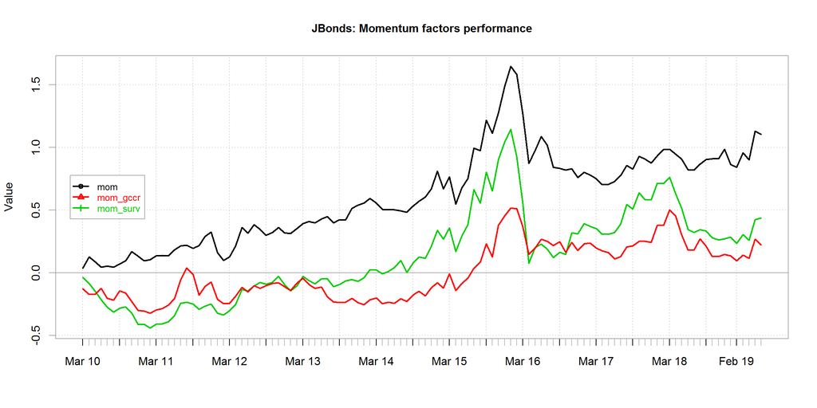

# The Factors Performance. JBonds. Momentum. Summary

- Survived (0 and 1): The momentum factor suffers from survivorship bias.
- Good (Only 1): The filtering lowers the momentum further.

# The Factors Performance. JBonds. Size

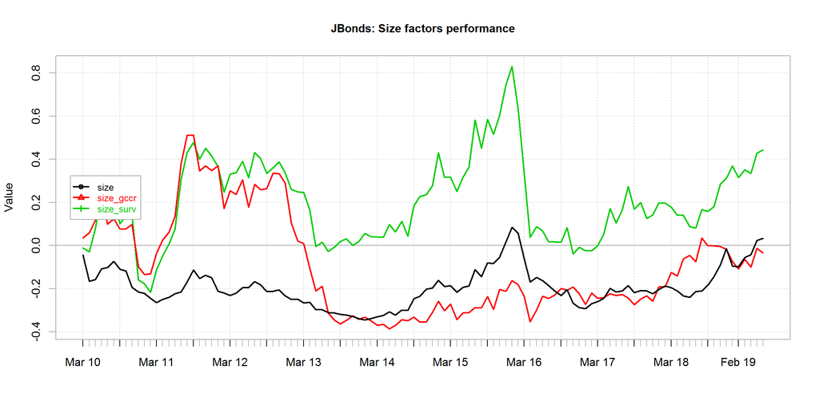

# The Factors Performance. JBonds. Size. Summary

- Survived (0 and 1): Here the survivorship bias significantly increase the performance!
- Good (Only 1): At the same time the filtering significantly reduces the performance.

# The Factors Performance. IGBonds. BM

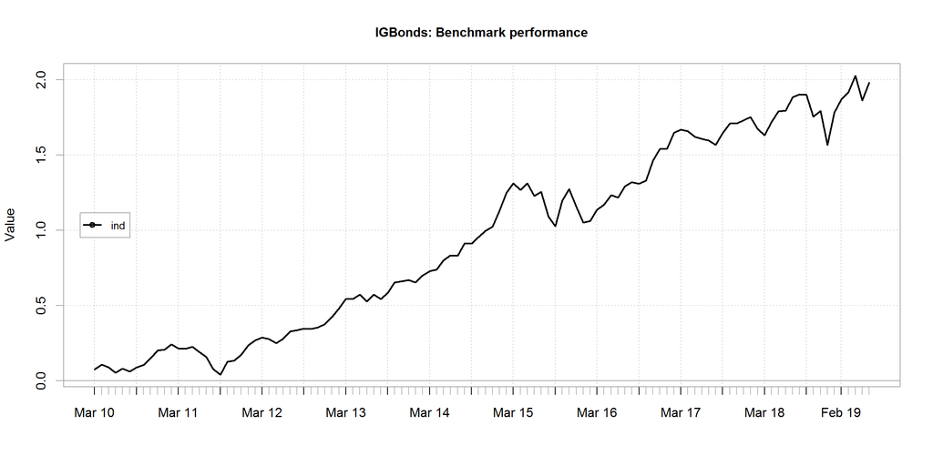

# The Factors Performance. IGBonds. BM. Summary

- The equally weighted index is also positive

# The Factors Performance. IGBonds. GCCR

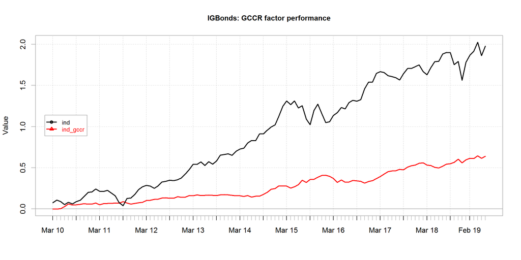

# The Factors Performance. IGBonds. GCCR. Summary

- GCCR factor is positive (but the value is only 0.6, significantly lower than the equal-weighted index).

# The Factors Performance. IGBonds. Momentum

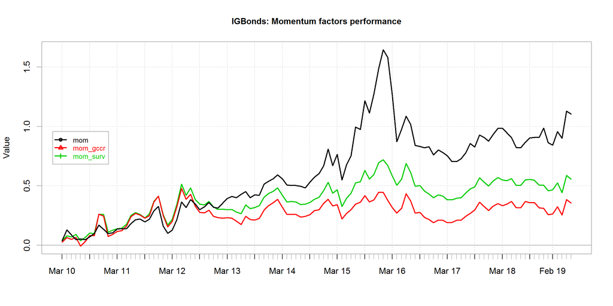

# The Factors Performance. IGBonds. Momentum. Summary

- Survived (0 and 1): The momentum factor suffers from survivorship bias.
- Good (Only 1): The filtering lowers the momentum further.

# The Factors Performance. IGBonds. Size

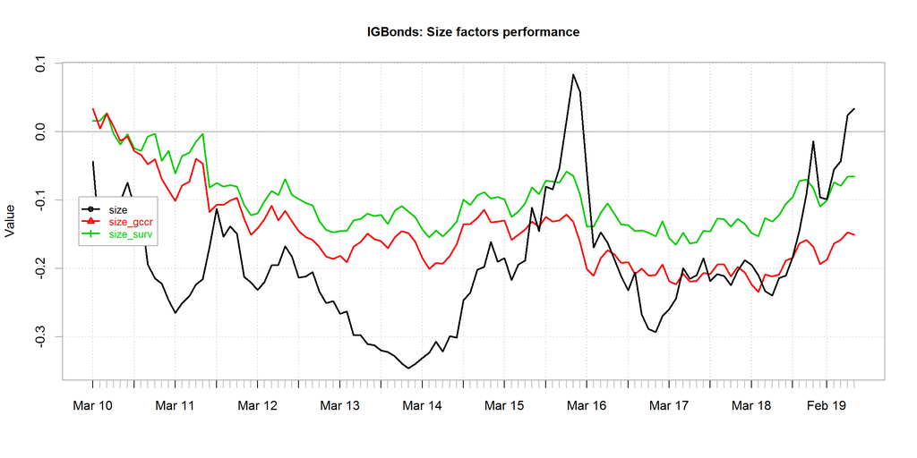

# The Factors Performance. IGBonds. Size. Summary

# Conclusions: Part 3

- Filtering reduces Value, Momentum and Size performance except of value in EM.

# The Factors Long Only Performance. USA. Value

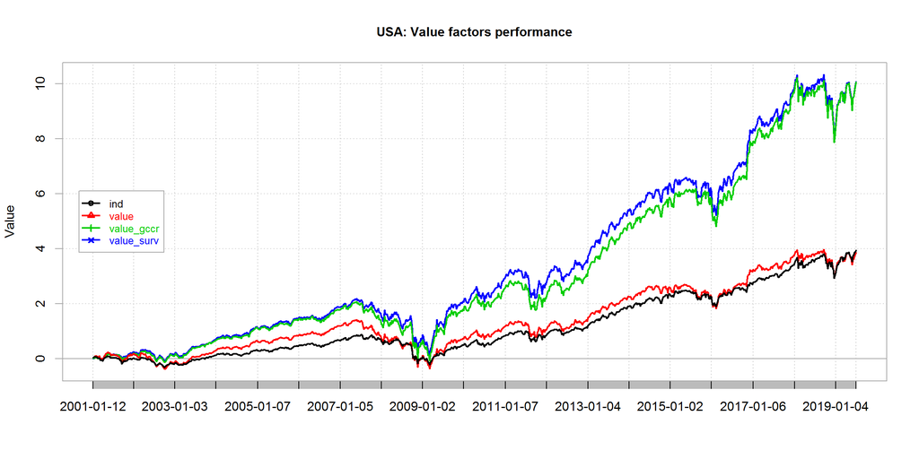

# The Factors Long Only Performance. USA. Value. Summary

- Overall, long-only factor performs much better.
- Survived (0 and 1): the performance is significantly improved by the survivorship bias.
- Good (Only 1): The filter lowers the performance compared with survived case.
- The benchmark here is equal-weighted index.

# The Factors Long Only Performance. USA. Momentum

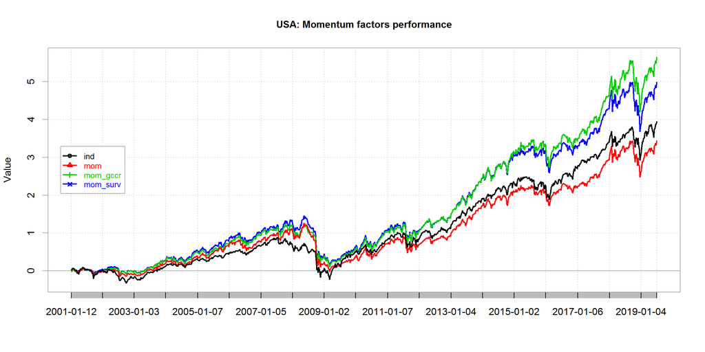

# The Factors Long Only Performance. USA. Momentum. Summary

- Overall, long-only factor performs much better.
- Original: the performance is positive.
- Survived (0 and 1): Survived portfolio performed better than the original one.
- Good (Only 1): the filtering improves the performance futher.
- The benchmark here is equal-weighted index.

# The Factors Long Only Performance. USA. Size

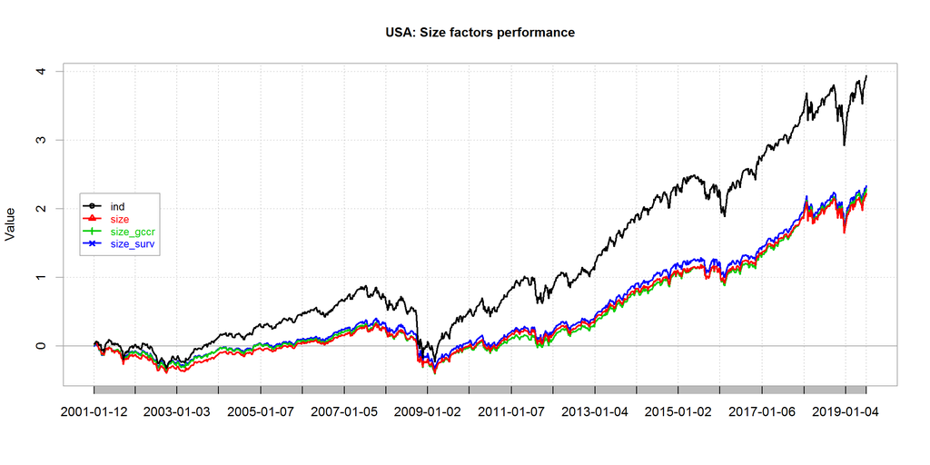

# The Factors Long Only Performance. USA. Size. Summary

# The Factors Long Only Performance. EUR. Value

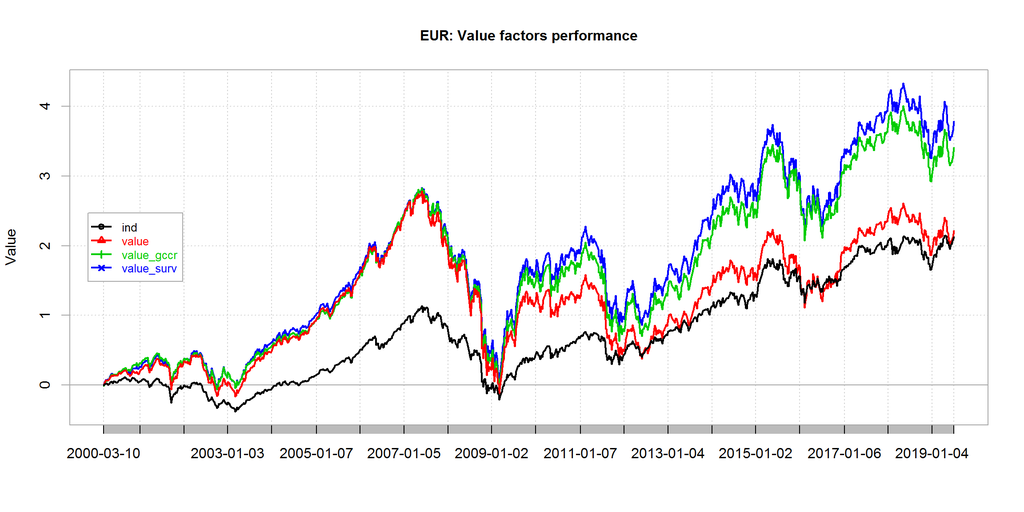

# The Factors Long Only Performance. EUR. Value. Summary

- Survived (0 and 1): The survivorship bias inproves the performance.
- Good (Only 1): The effect is decreased a bit.
- The benchmark here is equal-weighted index.

# The Factors Long Only Performance. EUR. Momentum

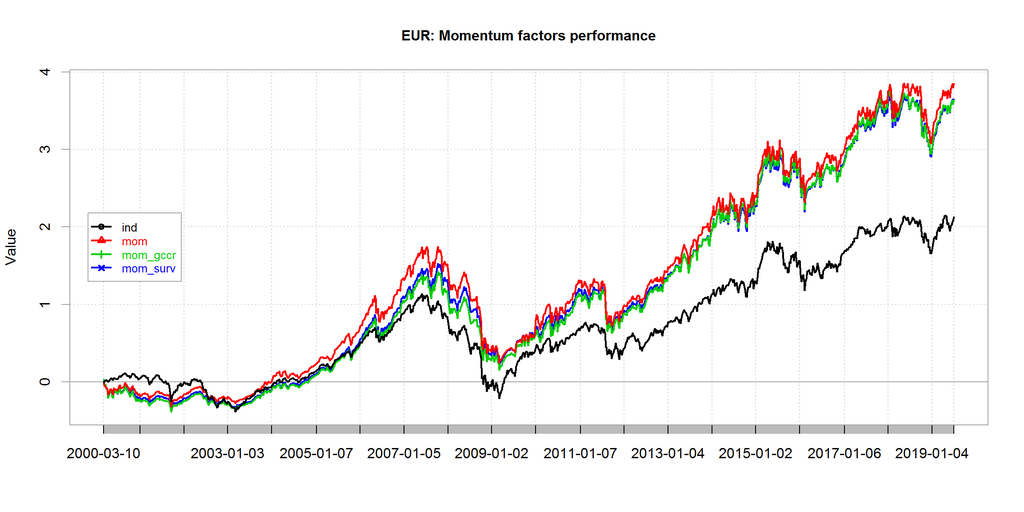

# The Factors Long Only Performance. EUR. Momentum. Summary

- Original Momentum performs positively.
- Survived (0 and 1): SustFilter slightly lowers the performance of Momentum factor in Europe.
- Good (Only 1): there is no additional effect.
- The benchmark here is equal-weighted index.

# The Factors Long Only Performance. EUR. Size

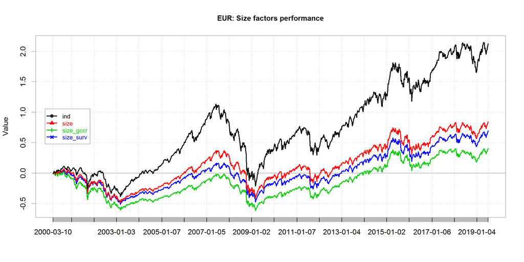

# The Factors Long Only Performance. EUR. Size. Summary

- Survived (0 and 1): The survivorship bias significantly lowers the performance of the size factor in Europe.
- Good (Only 1): The filter lowers the performance further.
- The benchmark here is equal-weighted index.

# The Factors Long Only Performance. EM. Value

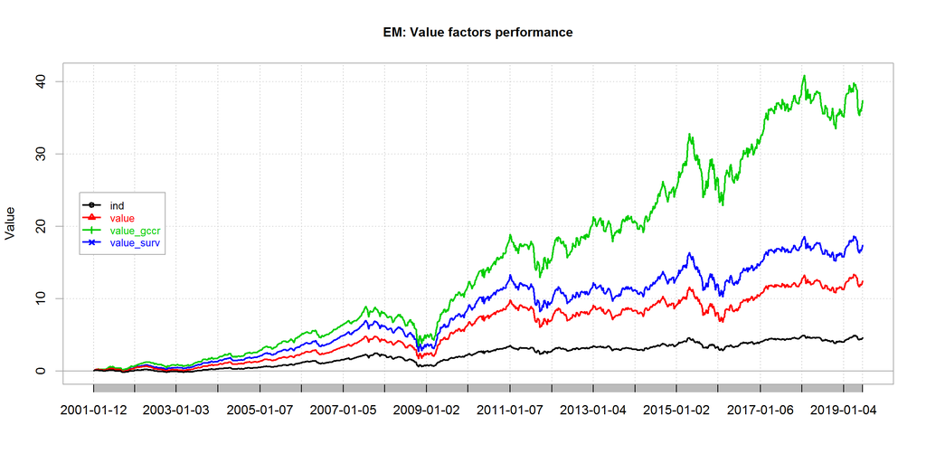

# The Factors Long Only Performance. EM. Value. Summary

- Original: performance is positive and much better than in the U.S. and the European markets.
- Survived (0 and 1): the survivorship bias increases the factor performance.
- Good (Only 1): the filtering also helps a lot!
- The benchmark here is equal-weighted index.

# The Factors Long Only Performance. EM. Momentum

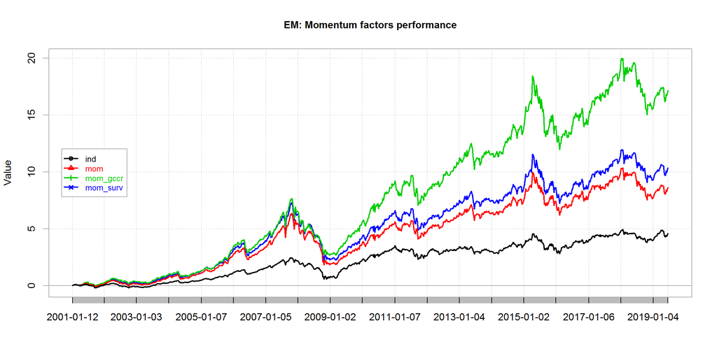

# The Factors Long Only Performance. EM. Momentum. Summary

- Original MOM performance is positive.
- Survived (0 and 1): the survivorship bias improves Momentum performance a bit.
- Good (Only 1): The filter increases Momentum performance further (significantly).
- The benchmark here is equal-weighted index.

# The Factors Long Only Performance. EM. Size

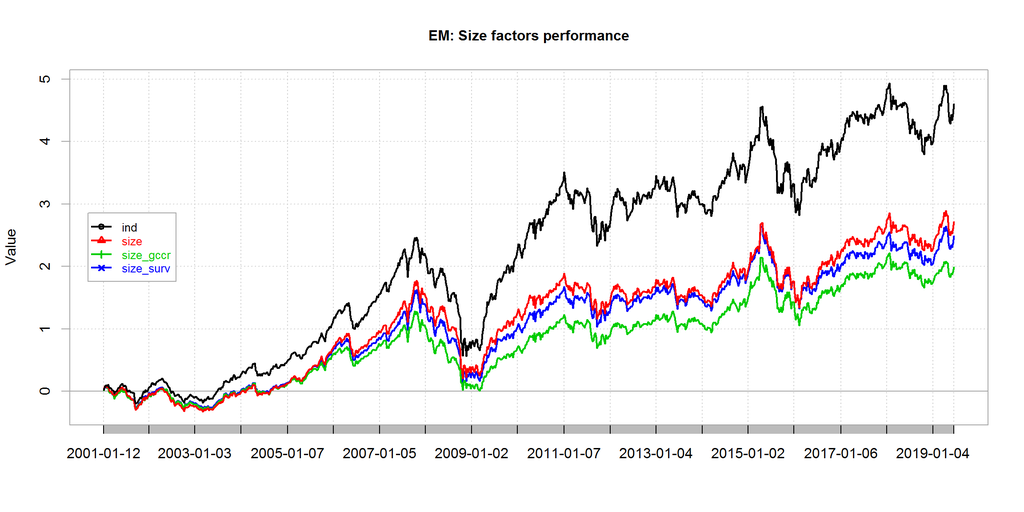

# The Factors Long Only Performance. EM. Size. Summary

- Original: the factor shows positive performance.
- Survived (0 and 1): the survivorship bias significantly lowers Size performance in the EM.
- Good (Only 1): the filter lowers performance further.
- The benchmark here is equal-weighted index.

# The Factors Long Only Performance. JBonds. Momentum

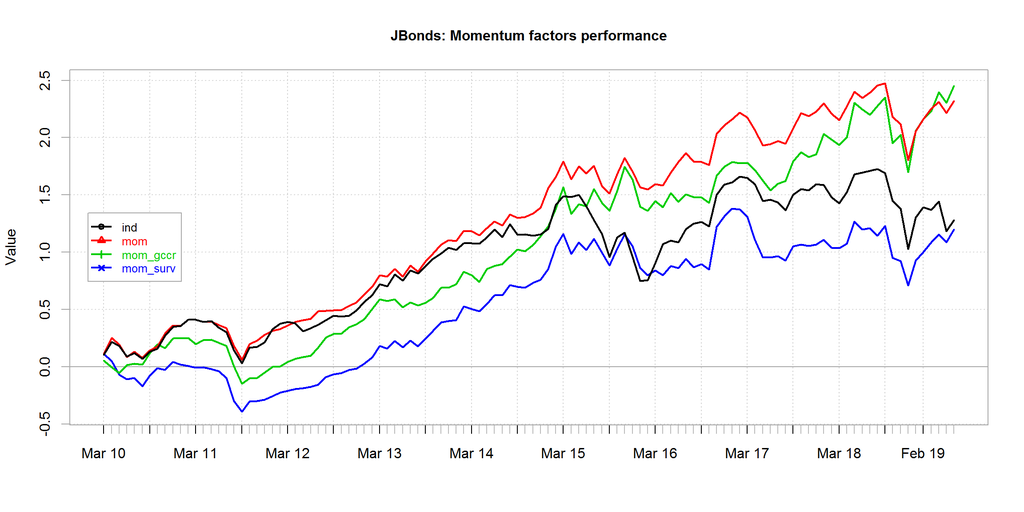

# The Factors Long Only Performance. JBonds. Momentum. Summary

- Survived (0 and 1): The momentum factor suffers from survivorship bias.
- Good (Only 1): The filtering, however, improves the momentum compared with the Survived case.
- The benchmark here is equal-weighted index.

# The Factors Long Only Performance. JBonds. Size

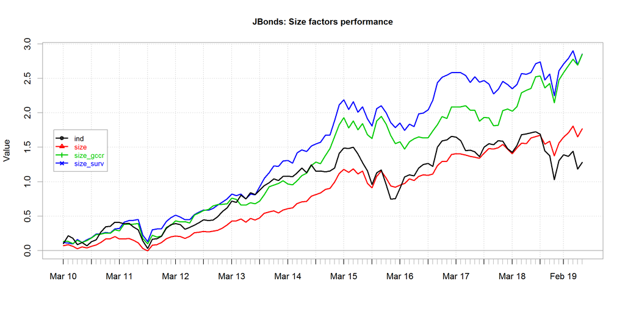

# The Factors Long Only Performance. JBonds. Size. Summary

- Survived (0 and 1): Here the survivorship bias significantly increase the performance!
- Good (Only 1): At the same time the filtering reduces the performance compared with the Survived case.
- The benchmark here is equal-weighted index.

# The Factors Long Only Performance. IGBonds. Momentum

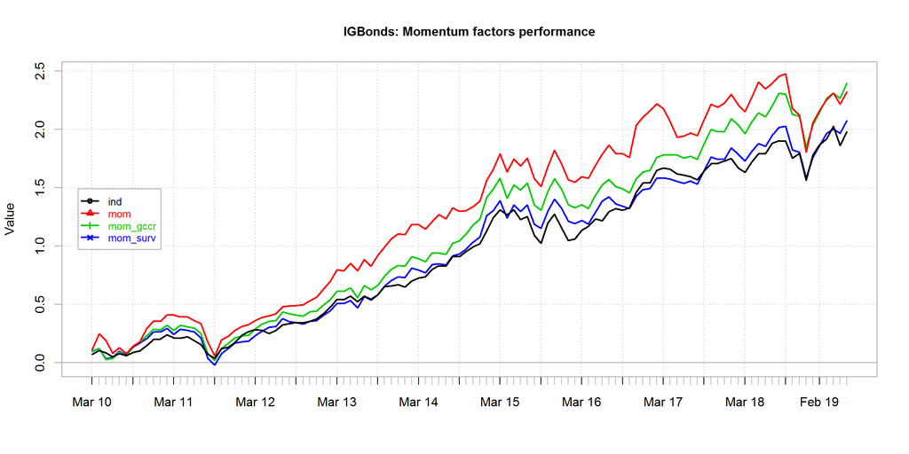

# The Factors Long Only Performance. IGBonds. Momentum. Summary

- Survived (0 and 1): The momentum factor suffers from the survivorship bias.
- Good (Only 1): The filtering, however, improves the momentum performance a bit compared with the Survived case.
- The benchmark here is equal-weighted index.

# The Factors Long Only Performance. IGBonds. Size

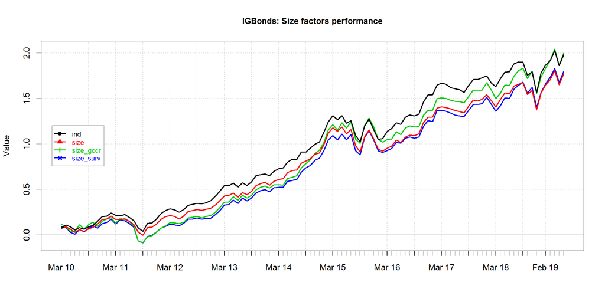

# The Factors Long Only Performance. IGBonds. Size. Summary

- Survived (0 and 1): Here the survivorship bias does not influence the performance.
- Good (Only 1): At the same time the filtering helps a bit.

# Conclusions: Part 4